# Evaluation of KNN classifier with Principal Component Analysis

Matteo Fasulo, Simone Flavio Paris, Matteo Sivoccia

07/12/2021

Packages used:

```r
source("https://raw.githubusercontent.com/MatteoFasulo/Rare-Earth/main/R/util/coreFunctions.R")
loadPackages(c('pacman','ggplot2','sn','corrplot','FactoMineR','factoextra',
               'caret','tidyverse','rgl'))
pacman::p_loaded()
```

```
##  [1] "rgl"        "forcats"    "stringr"    "dplyr"      "purrr"
##  [6] "readr"      "tidyr"      "tibble"     "tidyverse"  "caret"
## [11] "lattice"    "factoextra" "FactoMineR" "corrplot"   "sn"
## [16] "ggplot2"    "pacman"
```

```r
data(wines)
```

# 1 Dataset

Riassunto del dataset:

```r
wines
```

|  | wine | alcohol | sugar | acidity | tartaric | malic | uronic | pH | ash | alcal_ash | potassium | calcium | magnesium | phosphate | chloride | phenols | flavanoids | nonflavanoids | proanthocyanins | colour | hue | OD_dw | OD_fl | glycerol | butanediol | nitrogen | proline | methanol |
| --- | --- | --- | --- | --- | --- | --- | --- | --- | --- | --- | --- | --- | --- | --- | --- | --- | --- | --- | --- | --- | --- | --- | --- | --- | --- | --- | --- | --- |
| OLO0171 | Barolo | 14.23 | 24.82 | 73.1 | 1.21 | 1.71 | 0.72 | 3.38 | 2.43 | 15.6 | 950 | 62 | 127 | 320 | 82 | 2.80 | 3.06 | 0.28 | 2.29 | 5.640000 | 1.040 | 3.92 | 4.77 | 9.290000 | 757 | 153 | 1065 | 113 |
| OLO0271 | Barolo | 13.20 | 26.30 | 72.8 | 1.84 | 1.78 | 0.71 | 3.30 | 2.14 | 11.2 | 765 | 75 | 100 | 395 | 90 | 2.65 | 2.76 | 0.26 | 1.28 | 4.380000 | 1.050 | 3.40 | 3.80 | 8.930000 | 881 | 194 | 1050 | 94 |
| OLO0371 | Barolo | 13.16 | 26.30 | 68.5 | 1.94 | 2.36 | 0.84 | 3.48 | 2.67 | 18.6 | 936 | 70 | 101 | 497 | 67 | 2.80 | 3.24 | 0.30 | 2.81 | 5.680000 | 1.030 | 3.17 | 3.46 | 11.740000 | 900 | 206 | 1185 | 125 |
| OLO0471 | Barolo | 14.37 | 25.85 | 74.9 | 1.59 | 1.95 | 0.72 | 3.43 | 2.50 | 16.8 | 985 | 47 | 113 | 580 | 49 | 3.85 | 3.49 | 0.24 | 2.18 | 7.800000 | 0.860 | 3.45 | 3.54 | 10.130000 | 1119 | 292 | 1480 | 80 |
| OLO0571 | Barolo | 13.24 | 26.05 | 83.5 | 1.30 | 2.59 | 1.10 | 3.42 | 2.87 | 21.0 | 1088 | 70 | 118 | 408 | 65 | 2.80 | 2.69 | 0.39 | 1.82 | 4.320000 | 1.040 | 2.93 | 3.22 | 10.270000 | 799 | 215 | 735 | 73 |
| OLO0671 | Barolo | 14.20 | 28.40 | 79.9 | 2.14 | 1.76 | 0.96 | 3.39 | 2.45 | 15.2 | 868 | 71 | 112 | 418 | 58 | 3.27 | 3.39 | 0.34 | 1.97 | 6.750000 | 1.050 | 2.85 | 3.16 | 10.850000 | 865 | 364 | 1450 | 68 |
| OLO0771 | Barolo | 14.39 | 27.02 | 64.3 | 1.64 | 1.87 | 0.95 | 3.42 | 2.45 | 14.6 | 889 | 67 | 96 | 306 | 52 | 2.50 | 2.52 | 0.30 | 1.98 | 5.250000 | 1.020 | 3.58 | 3.94 | 9.050000 | 931 | 378 | 1290 | 80 |
| OLO0871 | Barolo | 14.06 | 26.40 | 73.5 | 1.33 | 2.15 | 1.14 | 3.54 | 2.61 | 17.6 | 894 | 50 | 121 | 502 | 64 | 2.60 | 2.51 | 0.31 | 1.25 | 5.050000 | 1.060 | 3.58 | 3.94 | 10.130000 | 865 | 358 | 1295 | 100 |
| OLO0971 | Barolo | 14.83 | 26.80 | 69.5 | 1.82 | 1.64 | 0.67 | 3.30 | 2.17 | 14.0 | 765 | 49 | 97 | 440 | 58 | 2.80 | 2.98 | 0.29 | 1.98 | 5.200000 | 1.080 | 2.85 | 3.03 | 9.890001 | 825 | 438 | 1045 | 141 |
| OLO1071 | Barolo | 13.86 | 27.00 | 68.5 | 1.92 | 1.35 | 0.67 | 3.27 | 2.27 | 16.0 | 794 | 51 | 98 | 391 | 64 | 2.98 | 3.15 | 0.22 | 1.85 | 7.220000 | 1.010 | 3.55 | 3.75 | 12.650000 | 788 | 350 | 1045 | 121 |

[output cut: 168 more lines]

# 2 Correlation Matrix

Abbiamo deciso, per prima cosa, di controllare la correlazione tra le variabili attraverso una rappresentazione grafica dove sia l’intensità del colore che il raggio di ogni circonferenza è proporzionale alla correlazione della variabile.

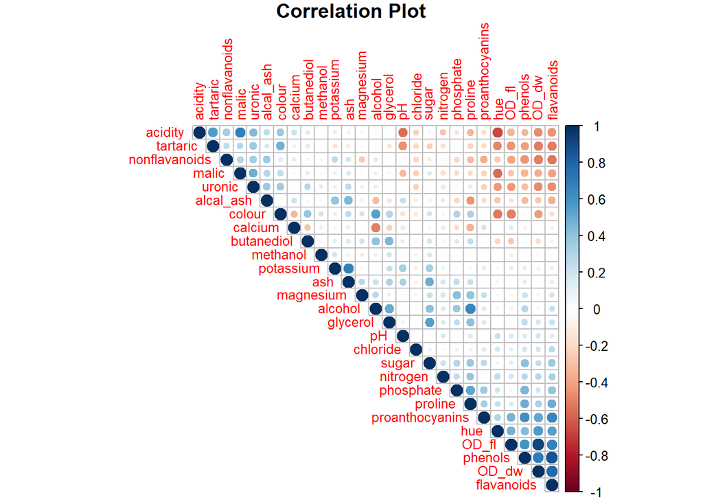

```r
corMatrix <- cor(wines[,-1])
plotCorr <- function(corMatrix){
  col <- colorRampPalette(c("#BB4444", "#EE9988", "#FFFFFF", "#77AADD", "#4477AA"))
  return(corrplot(corMatrix,
                  type="upper",
                  order="FPC",
                  sig.level = 0.01,
                  insig = "blank",
                  title = 'Correlation Plot',
                  tl.cex = .8,
                  mar=c(0,0,1,0)))
}
plotCorr(corMatrix)
```

Ci è sembrato opportuno nella nostra analisi considerare anche l’annata del vino ottenuta dalla trasformazione del nome di ogni osservazione.

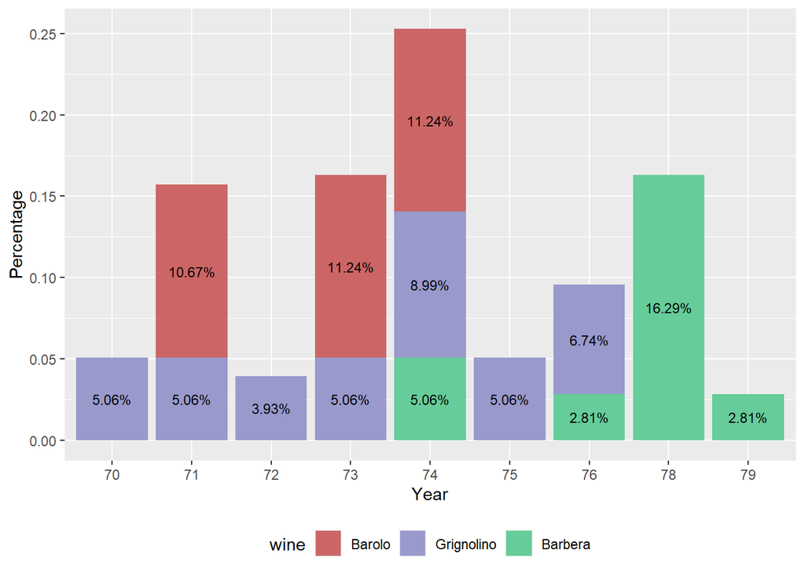

```r
year <- as.numeric(substr(rownames(wines), 6, 7))
wines[,'year'] <- year

wines %>%
    count(wine = factor(wine),
          year = factor(year)) %>%
    mutate(pct = prop.table(n)) %>%
    ggplot(aes(x = year, y = pct, fill = wine, label = scales::percent(pct))) +
    geom_col(position = 'stack') +
    geom_text(position = position_stack(vjust = 0.5),
              size = 3) +
    scale_y_continuous(name = "Percentage")+
    scale_x_discrete(name = "Year")+
    scale_fill_manual(values=c("#CC6666", "#9999CC", "#66CC99"))+
    theme(legend.position = "bottom")
```

# 3 PCA

Utilizzando la Principal Component Analysis abbiamo stimato le componenti principali che descrivono il nostro dataset, con l’aggiunta di 2 variaibli qualitative di supporto:

- Tipo di vino (Barolo, Barbera, Grignolino)
- Annata del vino

## 3.1 Screeplot

Dallo screeplot è possibile visualizzare la percentuale di varianza spiegata dalle componenti principali. Si noti come solamente le prime 2 costituiscono il 41% della varianza totale.

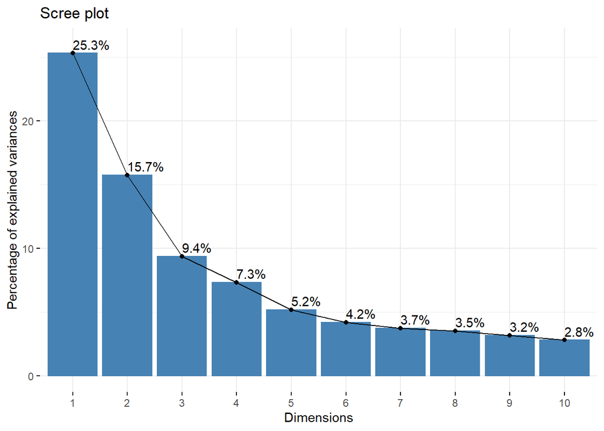

```r
fviz_screeplot(res, addlabels = TRUE, ylim = c(0, 26))
```

Riassunto dell’analisi delle componenti principali:

```r
summary(res, nbelements=10)
```

```
##
## Call:
## PCA(X = wines, quanti.sup = NULL, quali.sup = c(1, 29))
##
##
## Eigenvalues
##                        Dim.1   Dim.2   Dim.3   Dim.4   Dim.5   Dim.6   Dim.7
## Variance               6.832   4.251   2.528   1.978   1.393   1.125   1.002
## % of var.             25.303  15.746   9.363   7.325   5.160   4.167   3.713
## Cumulative % of var.  25.303  41.049  50.412  57.737  62.897  67.065  70.778
##                        Dim.8   Dim.9  Dim.10  Dim.11  Dim.12  Dim.13  Dim.14
## Variance               0.950   0.853   0.754   0.725   0.639   0.541   0.478
## % of var.              3.519   3.159   2.792   2.686   2.365   2.003   1.772
## Cumulative % of var.  74.296  77.455  80.247  82.933  85.298  87.301  89.073
##                       Dim.15  Dim.16  Dim.17  Dim.18  Dim.19  Dim.20  Dim.21
## Variance               0.439   0.379   0.340   0.320   0.276   0.243   0.214
## % of var.              1.626   1.403   1.259   1.185   1.020   0.900   0.794
## Cumulative % of var.  90.700  92.103  93.362  94.548  95.568  96.469  97.263
##                       Dim.22  Dim.23  Dim.24  Dim.25  Dim.26  Dim.27
## Variance               0.200   0.165   0.132   0.109   0.081   0.050
## % of var.              0.741   0.613   0.490   0.405   0.301   0.187
## Cumulative % of var.  98.004  98.617  99.107  99.512  99.813 100.000
##
## Individuals (the 10 first)
##                     Dist    Dim.1    ctr   cos2    Dim.2    ctr   cos2    Dim.3
## OLO0171         |  5.090 |  3.641  1.090  0.512 |  0.631  0.053  0.015 | -0.125
## OLO0271         |  4.163 |  2.447  0.492  0.346 | -0.359  0.017  0.007 | -2.206
## OLO0371         |  4.646 |  2.969  0.725  0.408 |  2.191  0.634  0.222 |  0.671
## OLO0471         |  6.663 |  4.185  1.440  0.394 |  3.848  1.956  0.334 | -0.766
## OLO0571         |  4.148 |  1.385  0.158  0.111 |  1.603  0.339  0.149 |  2.452
## OLO0671         |  5.185 |  3.116  0.798  0.361 |  2.902  1.113  0.313 | -0.943
## OLO0771         |  4.852 |  2.991  0.735  0.380 |  1.365  0.246  0.079 | -0.412
## OLO0871         |  5.054 |  3.030  0.755  0.359 |  2.494  0.822  0.243 |  0.469
## OLO0971         |  5.294 |  3.114  0.798  0.346 |  1.631  0.351  0.095 | -2.180
## OLO1071         |  4.870 |  3.448  0.978  0.501 |  1.591  0.335  0.107 | -1.542
##                    ctr   cos2
## OLO0171          0.003  0.001 |
## OLO0271          1.082  0.281 |
## OLO0371          0.100  0.021 |
## OLO0471          0.131  0.013 |
```

[output cut: 39 more lines]

```
## year.73         |   2.070 |   1.658   0.641   3.723 |  -0.157   0.006  -0.447 |
## year.74         |   0.907 |   0.680   0.561   2.012 |  -0.150   0.027  -0.564 |
## year.75         |   2.976 |   0.101   0.001   0.118 |  -2.139   0.516  -3.185 |
## year.76         |   2.357 |  -0.942   0.160  -1.558 |  -0.900   0.146  -1.886 |
##                   Dim.3    cos2  v.test
## Barolo           -0.340   0.012  -2.002 |
## Grignolino        0.368   0.029   2.511 |
## Barbera          -0.127   0.001  -0.647 |
## year.70          -1.608   0.225  -3.104 |
## year.71          -0.661   0.064  -2.389 |
## year.72           0.276   0.014   0.467 |
## year.73           0.859   0.172   3.171 |
## year.74          -0.292   0.103  -1.419 |
## year.75           1.064   0.128   2.054 |
## year.76           1.286   0.298   3.497 |
```

## 3.2 Individuals Plot

La libreria *fviz* ci ha permesso di rappresentare graficamente gli individui in funzione delle prime due componenti principali. Per semplicità di rappresentazione, vengono mostrati gli individui il cui cos2 è maggiore di 0.6 .

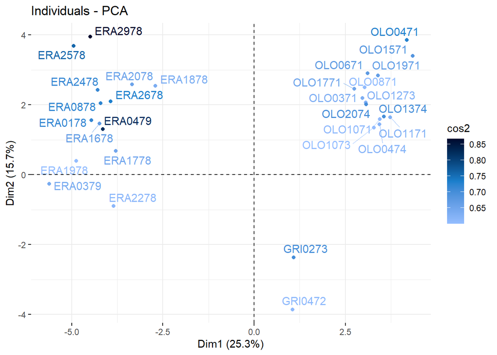

```r
fviz_pca_ind(res,
             col.ind="cos2",
             geom = c("point","text"),
             gradient.cols = c("#94bdff","#1b7fcc",'#00062e'),
             repel=T,
             select.ind= list(cos2 = .6),
             ggtheme=theme_minimal())
```

## 3.3 Variables Plot

Discorso analogo per quanto riguarda le variabili, selezionando le top 10 per cos2.

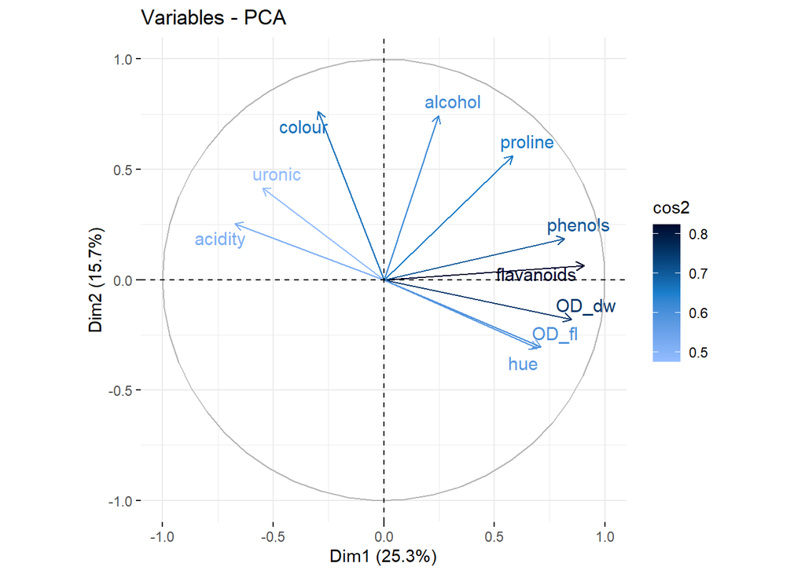

```r
fviz_pca_var(res, col.var = "cos2",
             gradient.cols = c("#94bdff","#1b7fcc",'#00062e'),
             select.var= list(cos2 = 10),
             repel = T,
             ggtheme = theme_minimal())
```

## 3.4 What’s Dim1 and Dim2?

```r
descDf <- data.frame("Category"=c('Alcohol/fermentation',NA,NA,NA,'Taste',NA,NA,NA,NA,NA,NA,NA,NA,'Mineral content',NA,NA,NA,NA,'Appearance',NA,NA,NA,'Other chemical elements',NA,NA,NA,NA),
                    "Variable"=c('Alcohol','Proline','Glycerol','Methanol','Phenols','NonFlavanoids','Flavanoids','Sugar','Acidity','Malic','Tartaric','Uronic','Proanthocyanins','Ash','Alcal-Ash','Magnesium','Potassium','Calcium','Hue','Colour','OD_dw','OD_fl','pH','Phosphate','Chloride','Butanediol','Nitrogen'),
                    "Dim"=c(2,2,NA,NA,1,NA,1,NA,1,NA,NA,1,NA,NA,NA,NA,NA,NA,1,2,1,1,NA,NA,NA,NA,NA))
data_blank <- descDf
data_blank <- sapply(data_blank, as.character)
data_blank[is.na(data_blank)] <- ""
as.data.frame(data_blank)
```

| Category | Variable | Dim |
| --- | --- | --- |
| Alcohol/fermentation | Alcohol | 2 |
|  | Proline | 2 |
|  | Glycerol |  |
|  | Methanol |  |
| Taste | Phenols | 1 |
|  | NonFlavanoids |  |
|  | Flavanoids | 1 |
|  | Sugar |  |
|  | Acidity | 1 |
|  | Malic |  |

[output cut: 17 more lines]

Abbiamo analizzato quali siano le variabili principali riassunte da ogni variabile sintetica, abbiamo notato alti valori del cos2 per la DIM1 con:

- Phenols
- Flavanoids
- Acidity
- Uronic
- Hue
- OD_dw
- OD_fl

Considerando che:

- le prime 4 variabili appartengono alla categoria *taste*
- *OD_dw* e *OD_fl* sono fortemente correlate a queste variabili nella *Correlation Matrix*

La dimensione 1 rappresenta principalmente l’ **intensità del sapore**.

Sulla dimensione 2 vi sono principalmente:

- Alcohol
- Proline
- Colour

E considerando che:

- Sia *Alcohol* che *Proline* sono misure della categoria di *Alcohol*/*fermentation*
- *Colour* è correlato positivamente con *Alcohol* nella *Correlation Matrix*

E’ ragionevole pensare che la dimensione 2 rappresenti i **livelli di fermentazione** e di **alcol**.

## 3.5 BiPlot

Combinando insieme le due precedenti rappresentazioni:

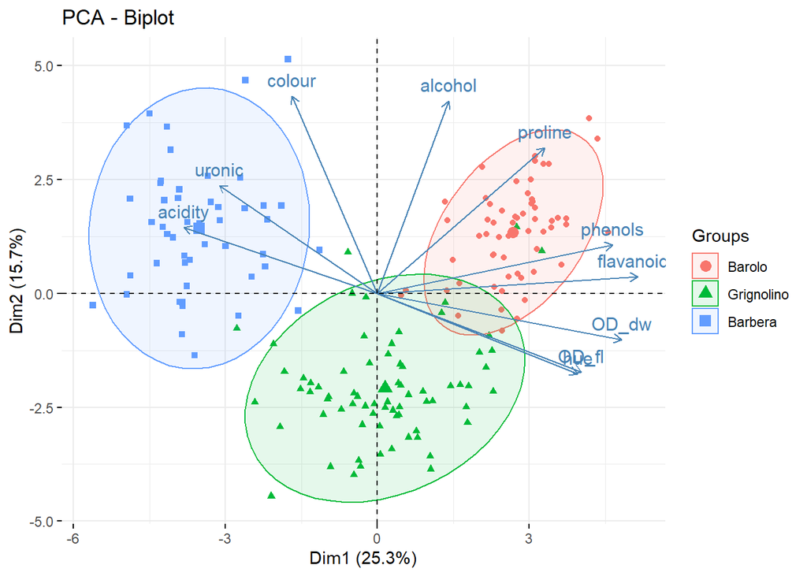

```r
fviz_pca_biplot(res, label = "var", habillage=wines$wine,
                addEllipses=TRUE, ellipse.level=0.90,
                ggtheme = theme_minimal(),
                select.var= list(cos2 = 10))
```

Possiamo notare come la dimensione 1 oppone (divide) in maniera forte i vini Barolo e Barbera.

I Barolo sono caratterizzati da: - **Alti valori** di *flavanoids*, *proline*, *phenols*, *OD_dw*, *alcohol*, *hue*. (variabili ordinate in maniera decrescente) - **Bassi valori** di *year* (sono quelli più vecchi infatti), *alcal_ash*, *acidity*

I Barbera sono caratterizzati da: (valori diversi in grassetto) - **Alti valori** di *acidity*, *year* (sono quelli più recenti infatti), **tartaric**, **malic**, **uronic**, *alcal_ash* e **colour** (variabili ordinate in maniera decrescente) - **Bassi valori** di *OD_dw*, **OD_fl**, *flavanoids*, *hue*, *phenols*, **roanthocyanins**, *proline*.

La dimensione 2 divide discretamente i Grignolino dai Barolo e Barbera. I Grignolino sono caratterizzati da: - **Alti valori** di *OD_fl*, **calcium**, *hue*. - **Bassi valori** di *alcohol*, *colour*, *ash*, *proline*, **magnesium**, **glycerol**, **sugar**. Notiamo anche che **i Grignolino sono altamente correlati con questa dimensione**, infatti possono riassumere da soli la dimensione 2.

## 3.6 Ellipses Plot

Considerando inoltre il fattore annata del vino:

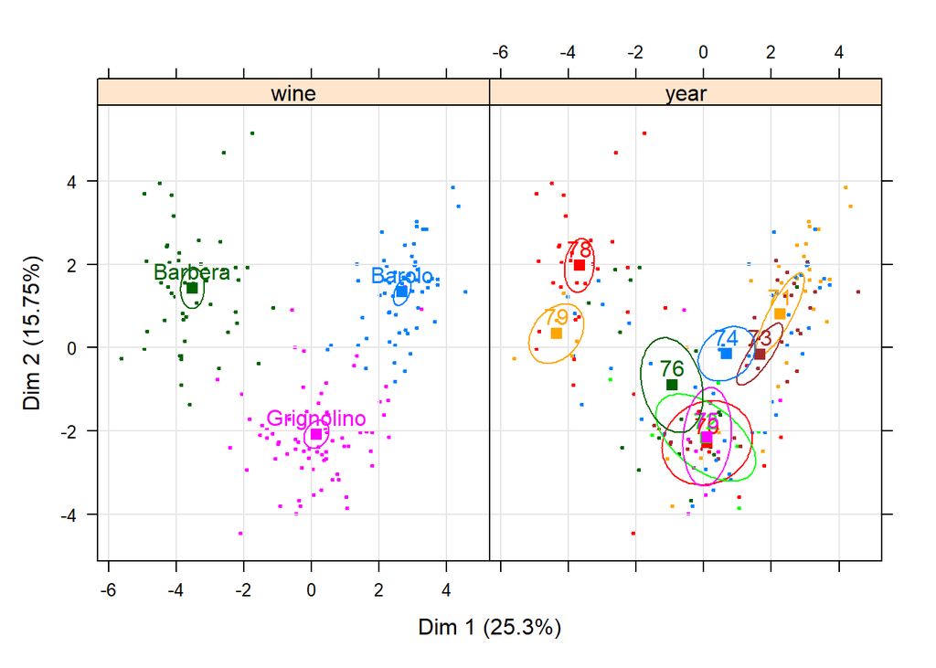

```r
plotellipses(model=res, autoLab = "auto")
```

## 3.7 What about 3rd and 4th dimension?

Per scrupolo, abbiamo controllato anche le componenti principali successive alla prima e seconda dimensione, notando che le osservazioni, sulla terza e quarta dimensione, non sono ben distinguibili.

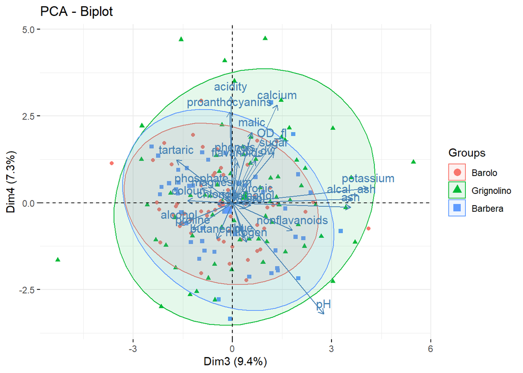

```r
fviz_pca_biplot(res, axes=c(3,4), label = "var", habillage=wines$wine,
                addEllipses=TRUE, ellipse.level=0.90,
                ggtheme = theme_minimal())
```

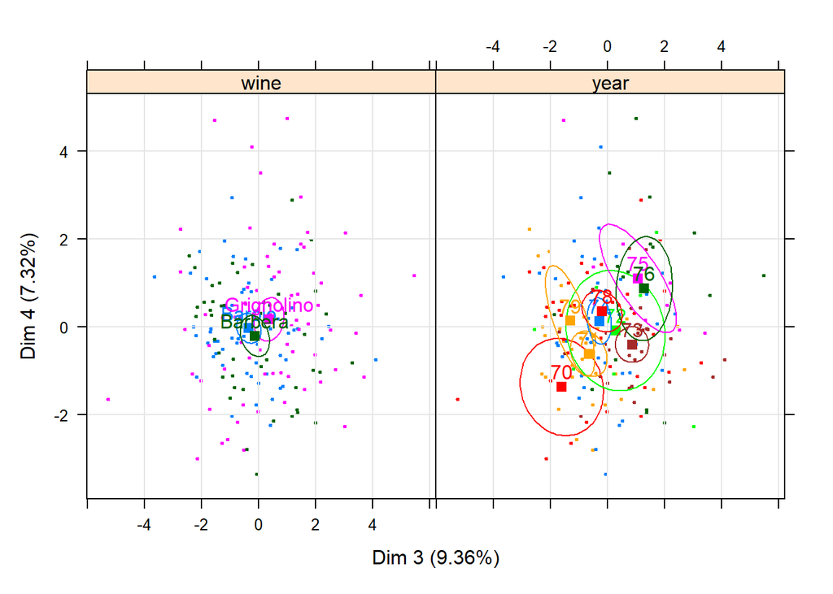

```r
plotellipses(model=res, axes=c(3,4), autoLab = "auto")
```

# 4 Splitting (using caret)

Volendo dunque utilizzare le componenti principali come base per una classificazione, abbiamo recuperato gli score per ogni osservazione dalle due dimensioni (DIM1 e DIM2), e diviso il dataset originario in una sezione di training ed una di testing. Lo split è effettuato secondo una proporzione di 0.7:

```r
set.seed(3033)
intrain <- createDataPartition(y = wines$wine, p=0.7, list = FALSE)
dim(intrain)
```

```
## [1] 126   1
```

# 5 KNN

Combinando in un unico dataframe i risultati della prima e della seconda componente principale è stato possibile applicare, tra i tanti metodi di classificazione, il KNN (K Nearest Neighbours) con Cross Validation 10-Fold:

```r
pc.comp <- res$ind$coord
pc.comp1 <- pc.comp[,1]
pc.comp2 <- pc.comp[,2]
X = cbind(pc.comp1, pc.comp2)
X = as.data.frame(cbind(wine=wines$wine, X))
X[which(X$wine==1),1] <- "Barolo"
X[which(X$wine==2),1] <- "Grignolino"
X[which(X$wine==3),1] <- "Barbera"
```

## 5.1 KNN-PC1

```r
trctrl <- trainControl(method = "repeatedcv", number = 10, repeats = 3)
set.seed(3333)
knn_fit.PC1 <- caret::train(wine ~ .-pc.comp2, data = X[intrain,], method = "knn",
                 trControl=trctrl,
                 preProcess = c("center", "scale"),
                 tuneLength = 10)
print(knn_fit.PC1)
```

```
## k-Nearest Neighbors
##
## 126 samples
##   2 predictor
##   3 classes: 'Barbera', 'Barolo', 'Grignolino'
##
## Pre-processing: centered (1), scaled (1)
## Resampling: Cross-Validated (10 fold, repeated 3 times)
## Summary of sample sizes: 113, 113, 113, 114, 113, 114, ...
## Resampling results across tuning parameters:
##
##   k   Accuracy   Kappa
##    5  0.8703602  0.8039569
##    7  0.8917277  0.8366649
##    9  0.8770452  0.8144087
##   11  0.8426435  0.7616690
##   13  0.8590965  0.7857366
##   15  0.8590965  0.7858118
##   17  0.8642247  0.7931839
##   19  0.8670024  0.7974822
##   21  0.8697802  0.8017823
##   23  0.8618742  0.7900367
##
## Accuracy was used to select the optimal model using the largest value.
## The final value used for the model was k = 7.
```

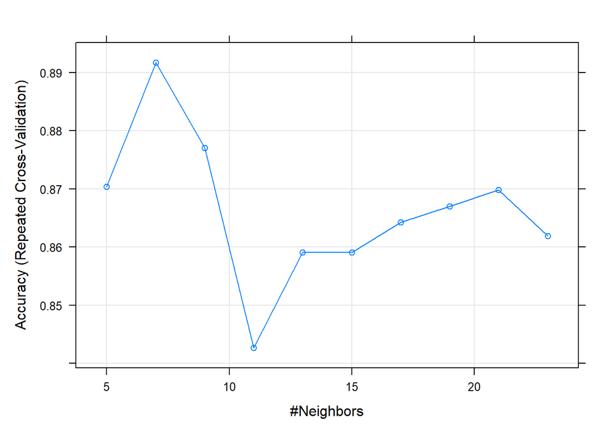

```r
plot(knn_fit.PC1)
```

```r
test_pred <- predict(knn_fit.PC1, newdata = X[-intrain,])
confusionMatrix(test_pred, as.factor(X[-intrain,'wine']))
```

```
## Confusion Matrix and Statistics
##
##             Reference
## Prediction   Barbera Barolo Grignolino
##   Barbera         11      0          1
##   Barolo           0     15          4
##   Grignolino       3      2         16
##
## Overall Statistics
##
##                Accuracy : 0.8077
##                  95% CI : (0.6747, 0.9037)
##     No Information Rate : 0.4038
##     P-Value [Acc > NIR] : 3.066e-09
##
##                   Kappa : 0.7065
##
##  Mcnemar's Test P-Value : NA
##
## Statistics by Class:
##
##                      Class: Barbera Class: Barolo Class: Grignolino
## Sensitivity                  0.7857        0.8824            0.7619
## Specificity                  0.9737        0.8857            0.8387
## Pos Pred Value               0.9167        0.7895            0.7619
## Neg Pred Value               0.9250        0.9394            0.8387
## Prevalence                   0.2692        0.3269            0.4038
## Detection Rate               0.2115        0.2885            0.3077
## Detection Prevalence         0.2308        0.3654            0.4038
## Balanced Accuracy            0.8797        0.8840            0.8003
```

## 5.2 KNN-PC2

```r
trctrl <- trainControl(method = "repeatedcv", number = 10, repeats = 3)
set.seed(3333)
knn_fit.PC2 <- caret::train(wine ~ .-pc.comp1, data = X[intrain,], method = "knn",
                 trControl=trctrl,
                 preProcess = c("center", "scale"),
                 tuneLength = 10)
print(knn_fit.PC2)
```

```
## k-Nearest Neighbors
##
## 126 samples
##   2 predictor
##   3 classes: 'Barbera', 'Barolo', 'Grignolino'
##
## Pre-processing: centered (1), scaled (1)
## Resampling: Cross-Validated (10 fold, repeated 3 times)
## Summary of sample sizes: 113, 113, 113, 114, 113, 114, ...
## Resampling results across tuning parameters:
##
##   k   Accuracy   Kappa
##    5  0.6830281  0.5153037
##    7  0.6549145  0.4722291
##    9  0.6345849  0.4433136
##   11  0.6361111  0.4451775
##   13  0.6517399  0.4674850
##   15  0.6630647  0.4828575
##   17  0.6713370  0.4949639
##   19  0.6841880  0.5134491
##   21  0.6743284  0.4968853
##   23  0.6794872  0.5041481
##
## Accuracy was used to select the optimal model using the largest value.
## The final value used for the model was k = 19.
```

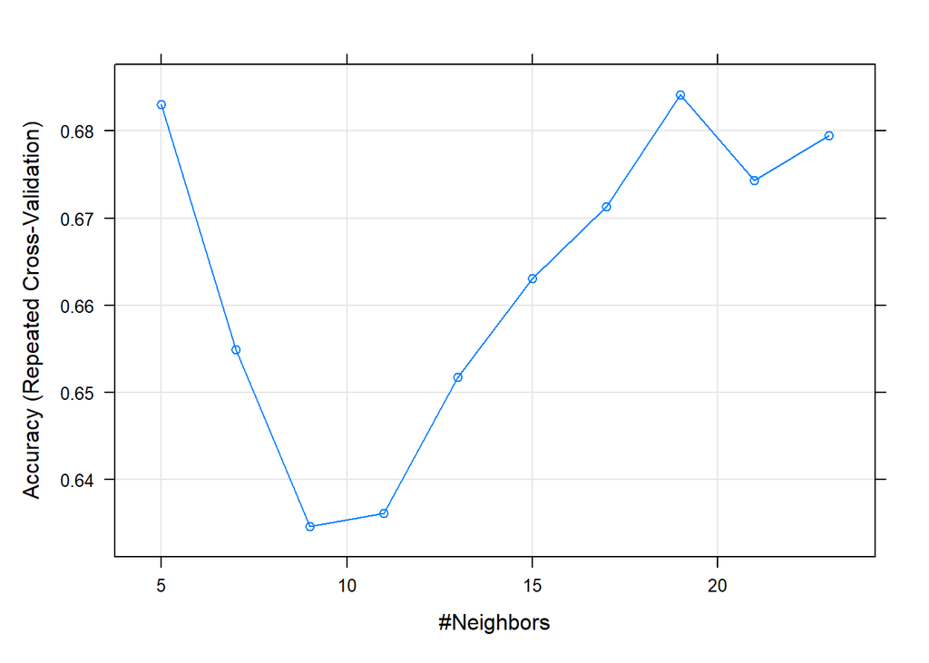

```r
plot(knn_fit.PC2)
```

```r
test_pred <- predict(knn_fit.PC2, newdata = X[-intrain,])
confusionMatrix(test_pred, as.factor(X[-intrain,'wine']))
```

```
## Confusion Matrix and Statistics
##
##             Reference
## Prediction   Barbera Barolo Grignolino
##   Barbera          3      5          0
##   Barolo           9     11          2
##   Grignolino       2      1         19
##
## Overall Statistics
##
##                Accuracy : 0.6346
##                  95% CI : (0.4896, 0.7638)
##     No Information Rate : 0.4038
##     P-Value [Acc > NIR] : 0.0006539
##
##                   Kappa : 0.4374
##
##  Mcnemar's Test P-Value : 0.3238633
##
## Statistics by Class:
##
##                      Class: Barbera Class: Barolo Class: Grignolino
## Sensitivity                 0.21429        0.6471            0.9048
## Specificity                 0.86842        0.6857            0.9032
## Pos Pred Value              0.37500        0.5000            0.8636
## Neg Pred Value              0.75000        0.8000            0.9333
## Prevalence                  0.26923        0.3269            0.4038
## Detection Rate              0.05769        0.2115            0.3654
## Detection Prevalence        0.15385        0.4231            0.4231
## Balanced Accuracy           0.54135        0.6664            0.9040
```

## 5.3 KNN-PC1+PC2

```r
trctrl <- trainControl(method = "repeatedcv", number = 10, repeats = 3)
set.seed(3333)
knn_fit.PC12 <- caret::train(wine ~ ., data = X[intrain,], method = "knn",
                 trControl=trctrl,
                 preProcess = c("center", "scale"),
                 tuneLength = 10)
print(knn_fit.PC12)
```

```
## k-Nearest Neighbors
##
## 126 samples
##   2 predictor
##   3 classes: 'Barbera', 'Barolo', 'Grignolino'
##
## Pre-processing: centered (2), scaled (2)
## Resampling: Cross-Validated (10 fold, repeated 3 times)
## Summary of sample sizes: 113, 113, 113, 114, 113, 114, ...
## Resampling results across tuning parameters:
##
##   k   Accuracy   Kappa
##    5  0.9679487  0.9514459
##    7  0.9707265  0.9557470
##    9  0.9679487  0.9514459
##   11  0.9679487  0.9514459
##   13  0.9786325  0.9676281
##   15  0.9786325  0.9676281
##   17  0.9811966  0.9715320
##   19  0.9811966  0.9715320
##   21  0.9784188  0.9674942
##   23  0.9758547  0.9635548
##
## Accuracy was used to select the optimal model using the largest value.
## The final value used for the model was k = 19.
```

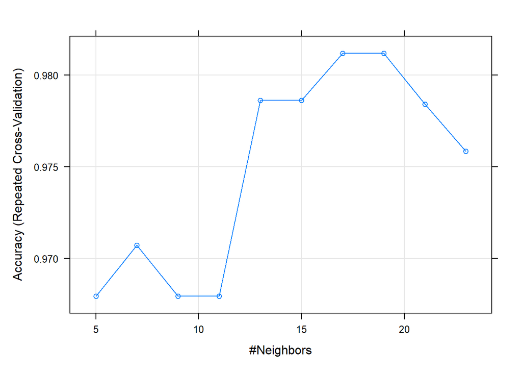

```r
plot(knn_fit.PC12)
```

```r
test_pred <- predict(knn_fit.PC12, newdata = X[-intrain,])
confusionMatrix(test_pred, as.factor(X[-intrain,'wine']))
```

```
## Confusion Matrix and Statistics
##
##             Reference
## Prediction   Barbera Barolo Grignolino
##   Barbera         12      0          2
##   Barolo           0     16          2
##   Grignolino       2      1         17
##
## Overall Statistics
##
##                Accuracy : 0.8654
##                  95% CI : (0.7421, 0.9441)
##     No Information Rate : 0.4038
##     P-Value [Acc > NIR] : 7.586e-12
##
##                   Kappa : 0.7957
##
##  Mcnemar's Test P-Value : NA
##
## Statistics by Class:
##
##                      Class: Barbera Class: Barolo Class: Grignolino
## Sensitivity                  0.8571        0.9412            0.8095
## Specificity                  0.9474        0.9429            0.9032
## Pos Pred Value               0.8571        0.8889            0.8500
## Neg Pred Value               0.9474        0.9706            0.8750
## Prevalence                   0.2692        0.3269            0.4038
## Detection Rate               0.2308        0.3077            0.3269
## Detection Prevalence         0.2692        0.3462            0.3846
## Balanced Accuracy            0.9023        0.9420            0.8564
```

## 5.4 KNN (without PCA)

```r
trctrl <- trainControl(method = "repeatedcv", number = 10, repeats = 3)
set.seed(3333)
knn_fit <- train(wine ~.-year, data = wines[intrain,], method = "knn",
                 trControl=trctrl,
                 preProcess = c("center", "scale"),
                 tuneLength = 10)
print(knn_fit)
```

```
## k-Nearest Neighbors
##
## 126 samples
##  28 predictor
##   3 classes: 'Barolo', 'Grignolino', 'Barbera'
##
## Pre-processing: centered (27), scaled (27)
## Resampling: Cross-Validated (10 fold, repeated 3 times)
## Summary of sample sizes: 113, 113, 113, 114, 113, 114, ...
## Resampling results across tuning parameters:
##
##   k   Accuracy   Kappa
##    5  0.9869658  0.9801365
##    7  0.9677350  0.9512990
##    9  0.9732906  0.9594734
##   11  0.9784188  0.9673896
##   13  0.9730769  0.9593443
##   15  0.9677350  0.9513867
##   17  0.9677350  0.9513867
##   19  0.9677350  0.9513867
##   21  0.9681319  0.9519910
##   23  0.9709096  0.9561577
##
## Accuracy was used to select the optimal model using the largest value.
## The final value used for the model was k = 5.
```

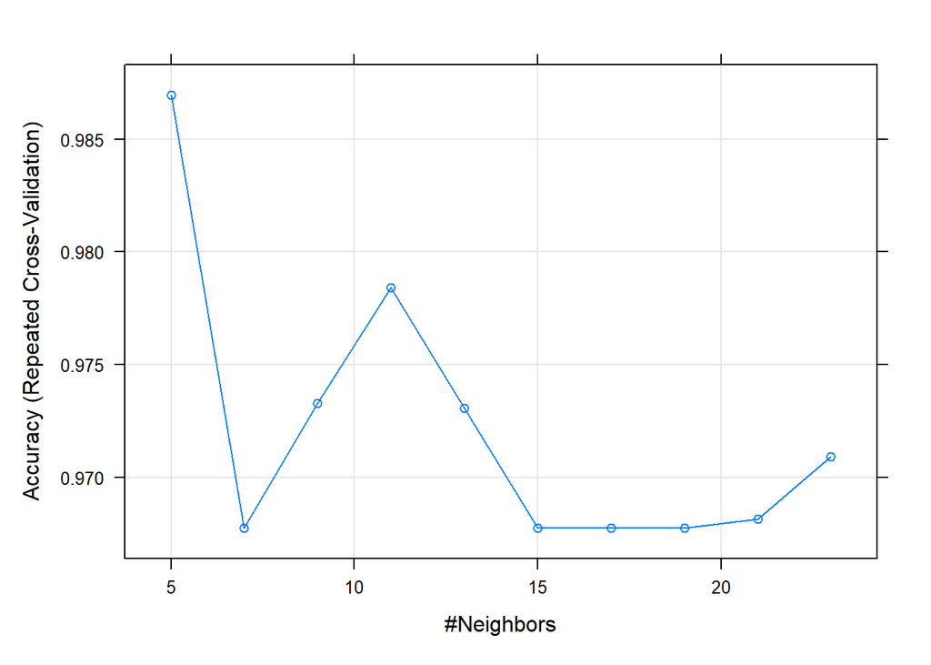

```r
plot(knn_fit)
```

```r
test_pred <- predict(knn_fit, newdata = wines[-intrain,])
confusionMatrix(test_pred, as.factor(wines[-intrain,1]))
```

```
## Confusion Matrix and Statistics
##
##             Reference
## Prediction   Barolo Grignolino Barbera
##   Barolo         17          0       0
##   Grignolino      0         21       0
##   Barbera         0          0      14
##
## Overall Statistics
##
##                Accuracy : 1
##                  95% CI : (0.9315, 1)
##     No Information Rate : 0.4038
##     P-Value [Acc > NIR] : < 2.2e-16
##
##                   Kappa : 1
##
##  Mcnemar's Test P-Value : NA
##
## Statistics by Class:
##
##                      Class: Barolo Class: Grignolino Class: Barbera
## Sensitivity                 1.0000            1.0000         1.0000
## Specificity                 1.0000            1.0000         1.0000
## Pos Pred Value              1.0000            1.0000         1.0000
## Neg Pred Value              1.0000            1.0000         1.0000
## Prevalence                  0.3269            0.4038         0.2692
## Detection Rate              0.3269            0.4038         0.2692
## Detection Prevalence        0.3269            0.4038         0.2692
## Balanced Accuracy           1.0000            1.0000         1.0000
```

## 5.5 KNN comparison

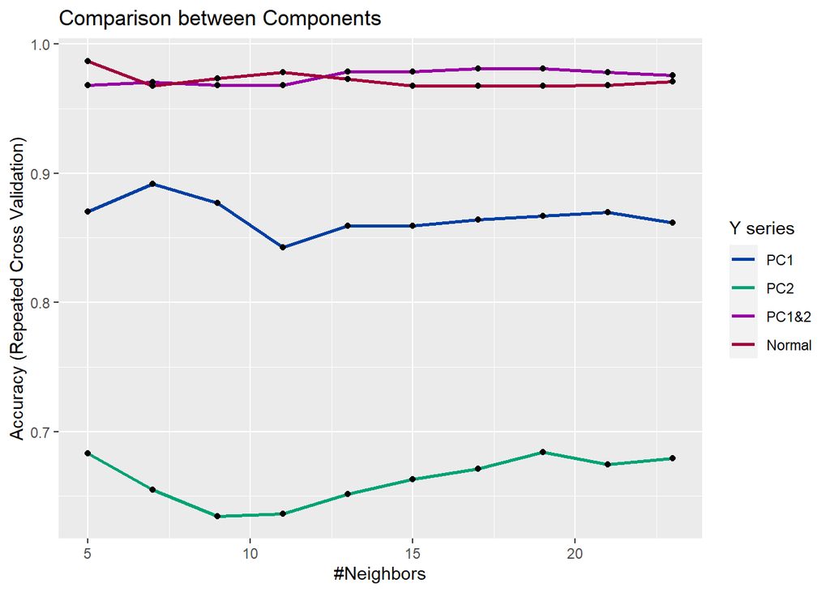

```r
knn.accuracyData = as.data.frame(cbind(PC1 = knn_fit.PC1$results$Accuracy,
                                       PC2 = knn_fit.PC2$results$Accuracy,
                                       PC12= knn_fit.PC12$results$Accuracy,
                                       NO_PCA = knn_fit$results$Accuracy))

ggplot(knn.accuracyData, aes(knn_fit.PC1$results$k)) +
  geom_line(aes(y = PC1, colour = "PC1"), size=1) + geom_point(aes(y = PC1)) +
  geom_line(aes(y = PC2, colour = "PC2"), size=1) + geom_point(aes(y = PC2)) +
  geom_line(aes(y = PC12, colour = "PC1&2"), size=1) + geom_point(aes(y = PC12)) +
  geom_line(aes(y = NO_PCA, colour = "Normal"), size=1) + geom_point(aes(y = NO_PCA)) +
  scale_color_manual(name = "Y series", values = c("PC1" = "#003fa3", "PC2" = "#00a375", "PC1&2" = "#9800a3", "Normal" = "#a3003c")) +
  ggtitle("Comparison between Components") +
  xlab("#Neighbors") + ylab("Accuracy (Repeated Cross Validation)")
```

# 6 Modellazione 3D

```r
# best 3 for separation
plot3d(wines$flavanoids, wines$OD_dw, wines$proline, type='s', size=2, col=as.numeric(wines$wine))
# worst 3 for separation
plot3d(wines$methanol, wines$potassium, wines$pH, type='s', size=2, col=as.numeric(wines$wine))
```

[output not shown]